# Visualize the FACETS profile for the TCGA dataset

In this notebook, we will visualize the FACETS profile (logR and logOR)

FACETS is an allele specific copy number analysis tool, therefore it performs analysis directly on SNPs. Although, FACETS requires that the tumor and normal sequence be from the same profile, so that the SNPs can be compared. However, our WES dataset does not provide matching normal sequences for each patient-derived tumor organoid. To see if FACETS is feasibly for calculating logR values, we will use the TCGA dataset to validate FACETS performance since the TCGA dataset provides matching normal sequences for multiple tumor patients.

### Import source libraries

```r
setwd("~/Documents/Git-Projects/Git-Research-Projects/drug-response-prediction")
library(facets)
source("facetsAnalysisLibrary.R")
```

### Define visualization function

```r
plotFacetsSample <- function(tumorId, normalId, silent = TRUE){
  try({
    setwd(paste0("~/Documents/Git-Projects/Git-Research-Projects/FACETS_nonmatching_test/"))
    fit <- getFacetsFit(tumorId, normalId, dir = "output/prev_run_4/")
    oo <- getFacetsOO(tumorId, normalId, dir = "output/prev_run_4/")
    print(paste0("FACETS Profile for tumorId=", tumorId, " normalId=", normalId))
    plotSample(x=oo, emfit = fit)
  }, silent = silent)
}
```

## Visualize FACETS profiles

Below, we see that the logOR values are much more noisy in the non-matching pairs compared to the matching pair. This was expected since the tumor & normal sequence was not measured from the same patient, therefore having different SNP profiles.

The inaccuracy in the logOR can effect downstream FACETS analysis such as segmentation, segmentation clustering, integer copy number calling, estimation of purity/ploidy/heterogeneity.

We will review the logR values in the following notebooks: "Visualize CORE TCGA Results" and "Visualize TCGA Variation".

### Visualization for tumorId=1

```
[1] "FACETS Profile for tumorId=1 normalId=1"
```

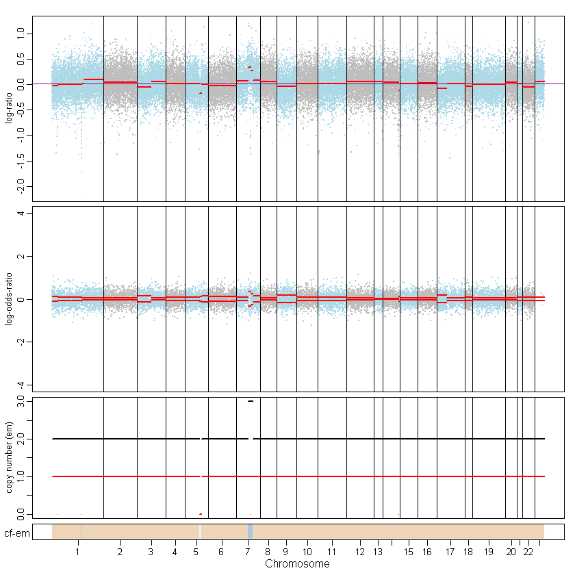

```r
plotFacetsSample(1, 1)
```

```
[1] "FACETS Profile for tumorId=1 normalId=2"
```

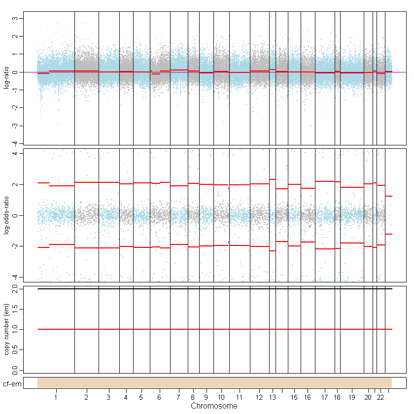

```r
plotFacetsSample(1, 2)
```

```
[1] "FACETS Profile for tumorId=1 normalId=5"
```

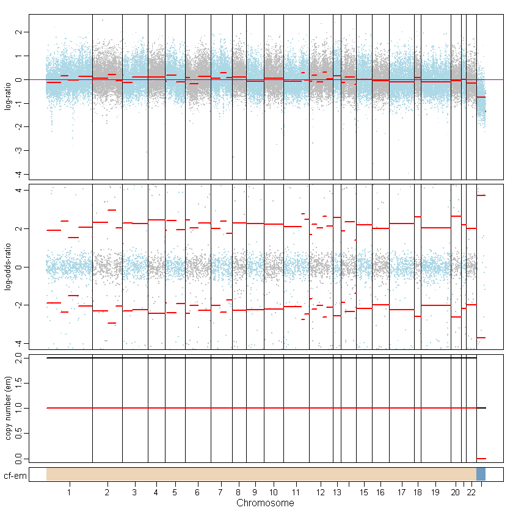

```r
plotFacetsSample(1, 5)
```

### Visualization for tumorId=2

```
[1] "FACETS Profile for tumorId=2 normalId=2"
```

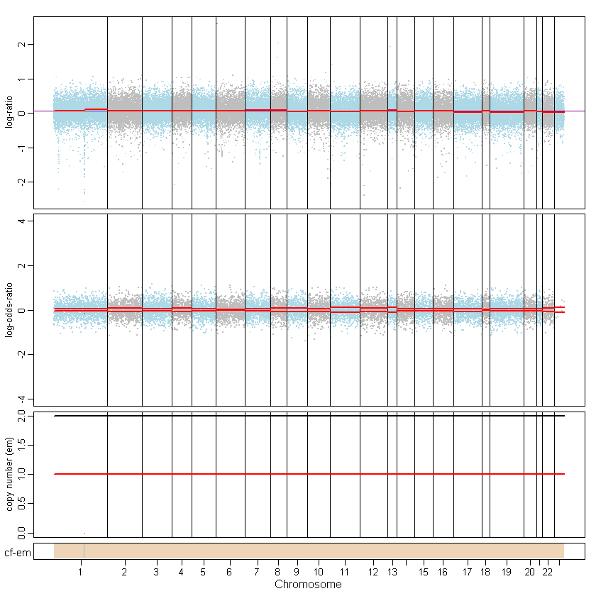

```r
plotFacetsSample(2, 2)
```

```
[1] "FACETS Profile for tumorId=2 normalId=1"
```

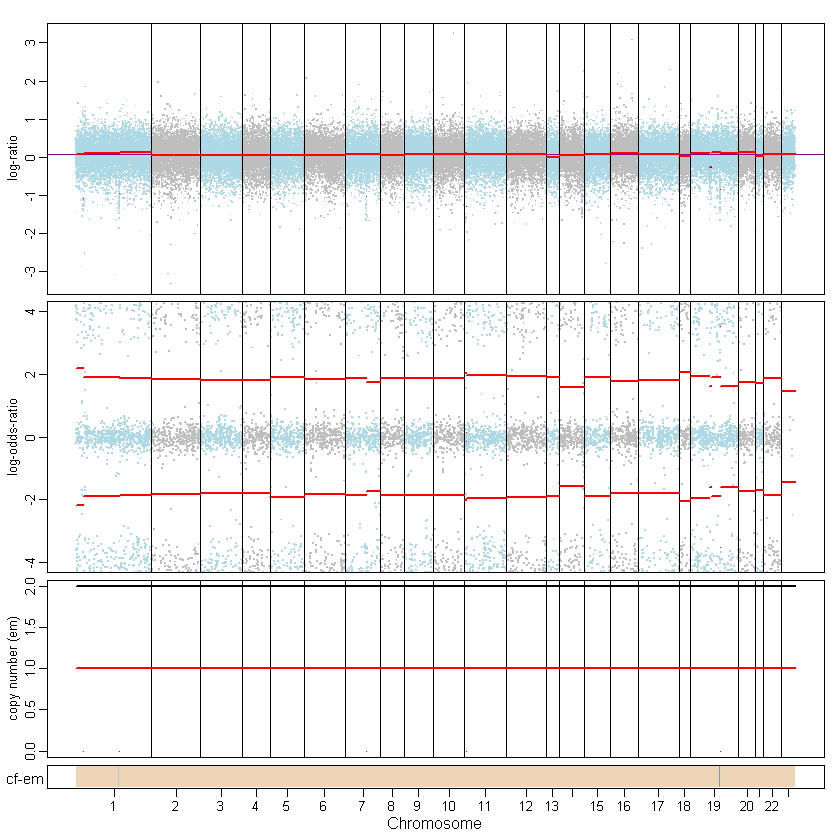

```r
plotFacetsSample(2, 1)
```

```
[1] "FACETS Profile for tumorId=2 normalId=3"
```

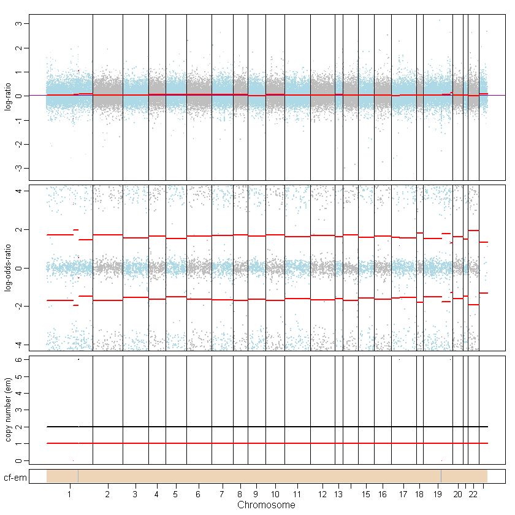

```r
plotFacetsSample(2, 3)
```

```
[1] "FACETS Profile for tumorId=2 normalId=4"
```

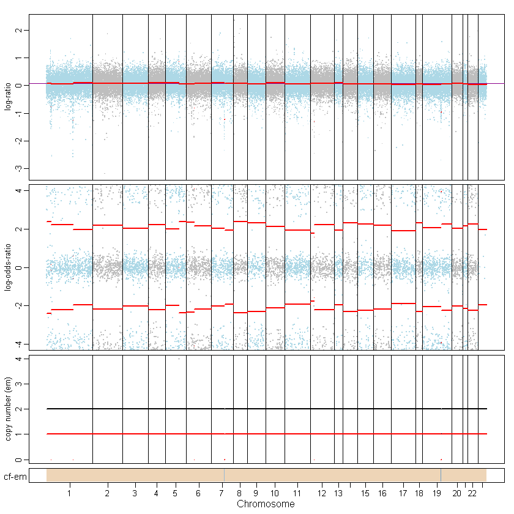

```r
plotFacetsSample(2, 4)
```

### Visualization for tumorId=5

```
[1] "FACETS Profile for tumorId=5 normalId=5"
```

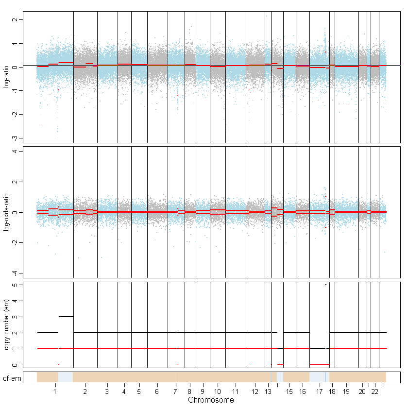

```r
plotFacetsSample(5, 5)
```

```
[1] "FACETS Profile for tumorId=5 normalId=6"
```

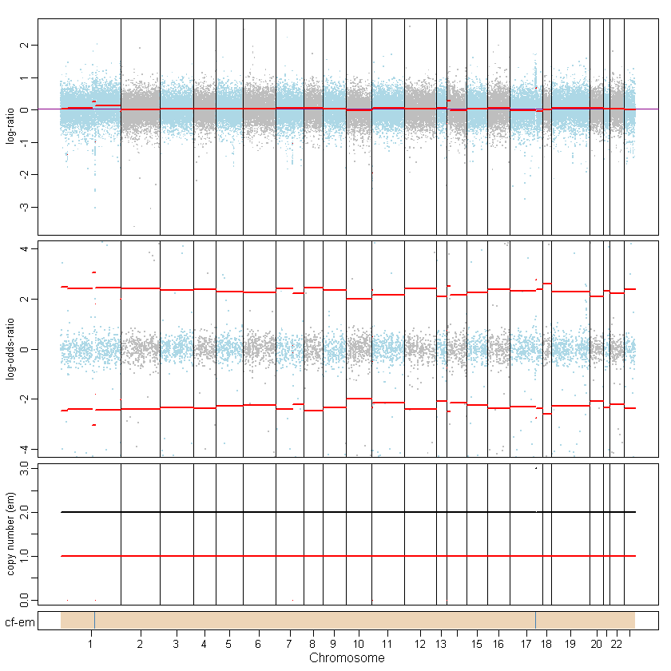

```r
plotFacetsSample(5, 6)
```

```
[1] "FACETS Profile for tumorId=5 normalId=7"
```

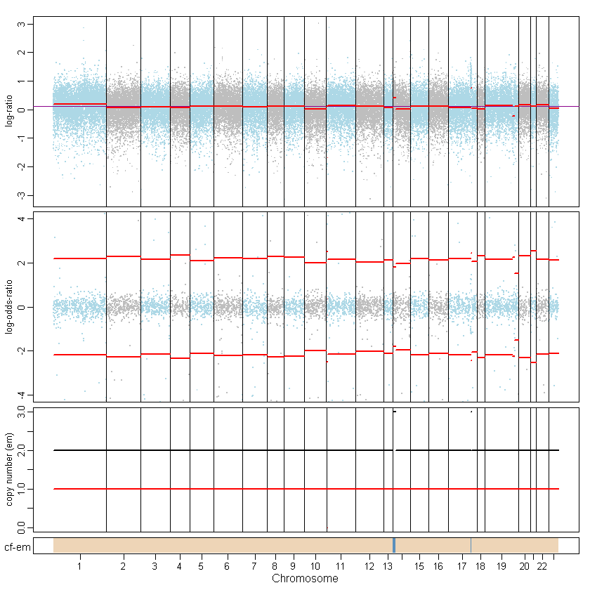

```r
plotFacetsSample(5, 7)
```

### Visualization for tumorId=6

```
[1] "FACETS Profile for tumorId=6 normalId=6"
```

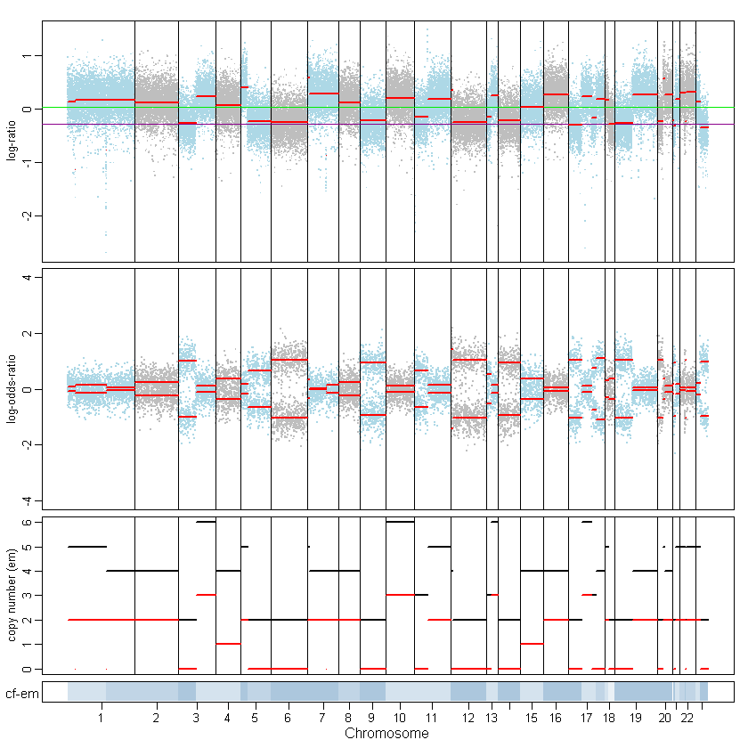

```r
plotFacetsSample(6, 6)
```

```
[1] "FACETS Profile for tumorId=6 normalId=7"
```

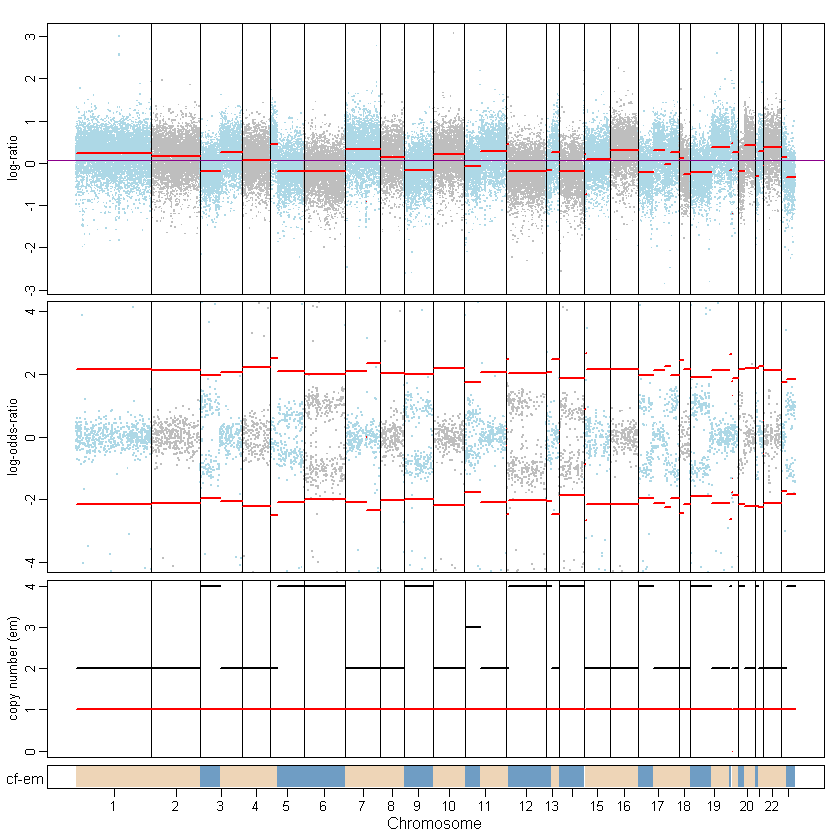

```r
plotFacetsSample(6, 7)
```

```
[1] "FACETS Profile for tumorId=6 normalId=5"
```

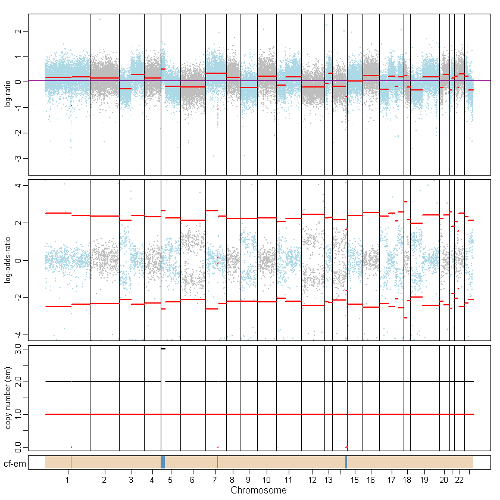

```r
plotFacetsSample(6, 5)
```

### Visualization for tumorId=7

```
[1] "FACETS Profile for tumorId=7 normalId=7"
```

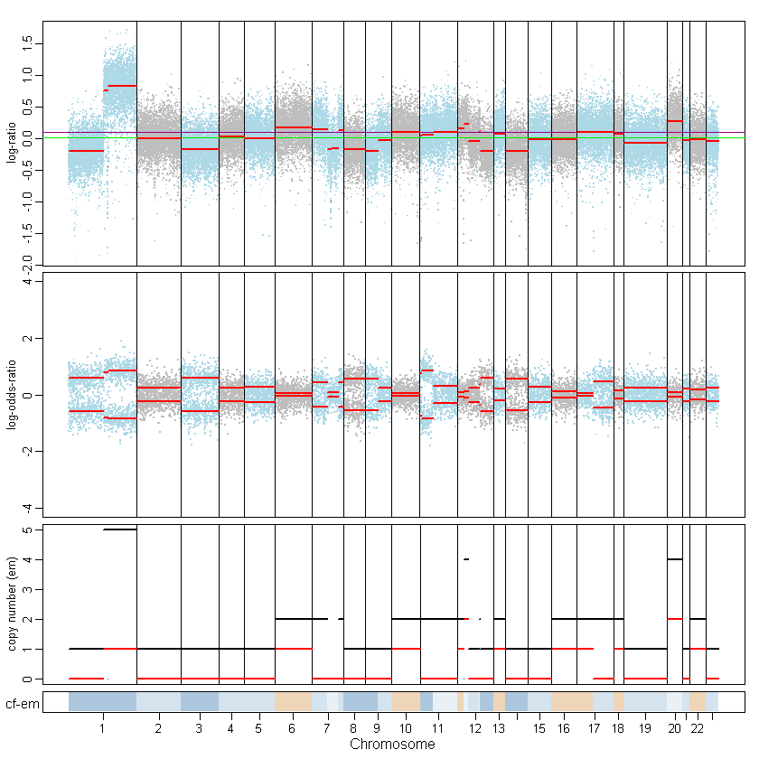

```r
plotFacetsSample(7, 7)
```

```
[1] "FACETS Profile for tumorId=7 normalId=1"
```

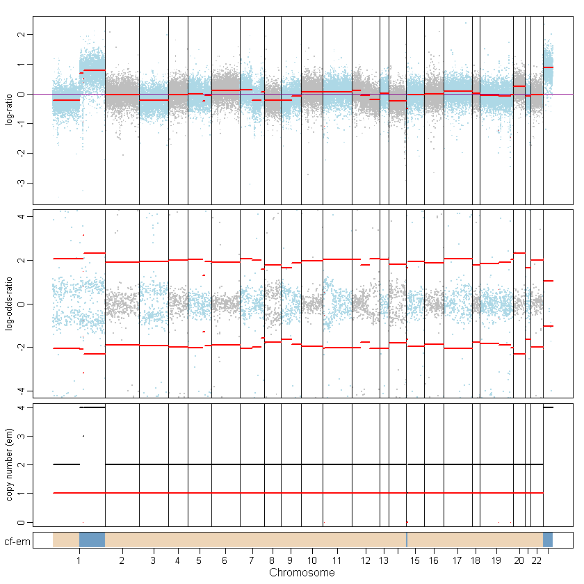

```r
plotFacetsSample(7, 1)
```

```
[1] "FACETS Profile for tumorId=7 normalId=2"
```

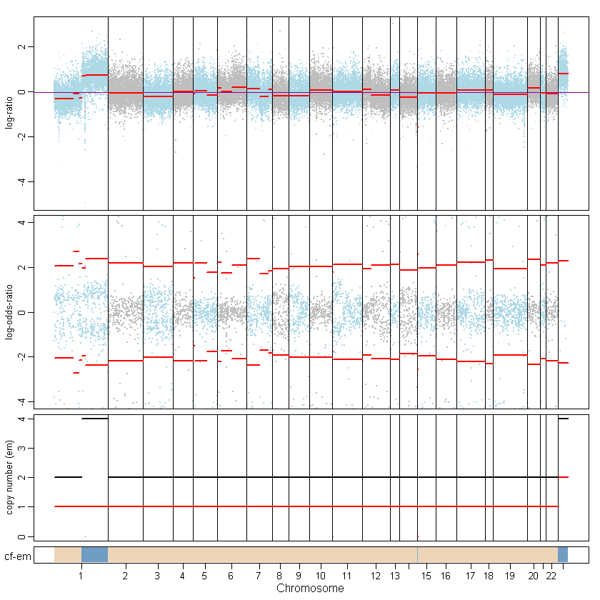

```r
plotFacetsSample(7, 2)
```